# Risk Factor Analysis

## Outcome Variable

**Outcome Variable:** ever_co

## Predictor Variables

**Intervention Variable:** exclfeed3

**Adjustment Set:**

- arm
- sex
- W_mage
- meducyrs
- feducyrs
- hhwealth_quart
- hfoodsec
- W_mhtcm
- vagbrth
- W_gagebrth
- W_birthwt
- W_birthlen
- W_nrooms
- W_nchldlt5
- month
- brthmon
- W_parity
- impfloor
- impsan
- safeh20
- delta_W_mage
- delta_meducyrs
- delta_feducyrs
- delta_hhwealth_quart
- delta_hfoodsec
- delta_W_mhtcm
- delta_vagbrth
- delta_W_gagebrth
- delta_W_birthwt
- delta_W_birthlen
- delta_W_nrooms
- delta_W_nchldlt5
- delta_month
- delta_brthmon
- delta_W_parity
- delta_impfloor
- delta_impsan
- delta_safeh20

## Stratifying Variables

The analysis was stratified on these variable(s):

- agecat
- studyid
- country

## Data Summary

| agecat | studyid | country | exclfeed3 | ever_co | n_cell | n |
| --- | --- | --- | --- | --- | --- | --- |
| 0-24 months | ki0047075b-MAL-ED | BANGLADESH | 1 | 0 | 149 | 248 |
| 0-24 months | ki0047075b-MAL-ED | BANGLADESH | 1 | 1 | 32 | 248 |
| 0-24 months | ki0047075b-MAL-ED | BANGLADESH | 0 | 0 | 61 | 248 |
| 0-24 months | ki0047075b-MAL-ED | BANGLADESH | 0 | 1 | 6 | 248 |
| 0-24 months | ki0047075b-MAL-ED | BRAZIL | 1 | 0 | 84 | 225 |
| 0-24 months | ki0047075b-MAL-ED | BRAZIL | 1 | 1 | 1 | 225 |
| 0-24 months | ki0047075b-MAL-ED | BRAZIL | 0 | 0 | 139 | 225 |
| 0-24 months | ki0047075b-MAL-ED | BRAZIL | 0 | 1 | 1 | 225 |
| 0-24 months | ki0047075b-MAL-ED | INDIA | 1 | 0 | 116 | 240 |
| 0-24 months | ki0047075b-MAL-ED | INDIA | 1 | 1 | 30 | 240 |
| 0-24 months | ki0047075b-MAL-ED | INDIA | 0 | 0 | 70 | 240 |
| 0-24 months | ki0047075b-MAL-ED | INDIA | 0 | 1 | 24 | 240 |
| 0-24 months | ki0047075b-MAL-ED | NEPAL | 1 | 0 | 76 | 235 |
| 0-24 months | ki0047075b-MAL-ED | NEPAL | 1 | 1 | 10 | 235 |
| 0-24 months | ki0047075b-MAL-ED | NEPAL | 0 | 0 | 139 | 235 |
| 0-24 months | ki0047075b-MAL-ED | NEPAL | 0 | 1 | 10 | 235 |
| 0-24 months | ki0047075b-MAL-ED | PERU | 1 | 0 | 67 | 286 |
| 0-24 months | ki0047075b-MAL-ED | PERU | 1 | 1 | 3 | 286 |
| 0-24 months | ki0047075b-MAL-ED | PERU | 0 | 0 | 208 | 286 |
| 0-24 months | ki0047075b-MAL-ED | PERU | 0 | 1 | 8 | 286 |
| 0-24 months | ki0047075b-MAL-ED | SOUTH AFRICA | 1 | 0 | 34 | 275 |
| 0-24 months | ki0047075b-MAL-ED | SOUTH AFRICA | 1 | 1 | 0 | 275 |
| 0-24 months | ki0047075b-MAL-ED | SOUTH AFRICA | 0 | 0 | 220 | 275 |
| 0-24 months | ki0047075b-MAL-ED | SOUTH AFRICA | 0 | 1 | 21 | 275 |
| 0-24 months | ki0047075b-MAL-ED | TANZANIA, UNITED REPUBLIC OF | 1 | 0 | 65 | 249 |
| 0-24 months | ki0047075b-MAL-ED | TANZANIA, UNITED REPUBLIC OF | 1 | 1 | 4 | 249 |
| 0-24 months | ki0047075b-MAL-ED | TANZANIA, UNITED REPUBLIC OF | 0 | 0 | 161 | 249 |
| 0-24 months | ki0047075b-MAL-ED | TANZANIA, UNITED REPUBLIC OF | 0 | 1 | 19 | 249 |
| 0-24 months | ki1000108-CMC-V-BCS-2002 | INDIA | 1 | 0 | 7 | 10 |
| 0-24 months | ki1000108-CMC-V-BCS-2002 | INDIA | 1 | 1 | 3 | 10 |

[output cut: 162 more lines]

The following strata were considered:

- agecat: 0-24 months, studyid: ki0047075b-MAL-ED, country: BANGLADESH
- agecat: 0-24 months, studyid: ki0047075b-MAL-ED, country: BRAZIL
- agecat: 0-24 months, studyid: ki0047075b-MAL-ED, country: INDIA
- agecat: 0-24 months, studyid: ki0047075b-MAL-ED, country: NEPAL
- agecat: 0-24 months, studyid: ki0047075b-MAL-ED, country: PERU
- agecat: 0-24 months, studyid: ki0047075b-MAL-ED, country: SOUTH AFRICA
- agecat: 0-24 months, studyid: ki0047075b-MAL-ED, country: TANZANIA, UNITED REPUBLIC OF
- agecat: 0-24 months, studyid: ki1000108-CMC-V-BCS-2002, country: INDIA
- agecat: 0-24 months, studyid: ki1000108-IRC, country: INDIA
- agecat: 0-24 months, studyid: ki1000109-EE, country: PAKISTAN
- agecat: 0-24 months, studyid: ki1000304b-SAS-CompFeed, country: INDIA
- agecat: 0-24 months, studyid: ki1017093b-PROVIDE, country: BANGLADESH
- agecat: 0-24 months, studyid: ki1101329-Keneba, country: GAMBIA
- agecat: 0-24 months, studyid: ki1113344-GMS-Nepal, country: NEPAL
- agecat: 0-24 months, studyid: kiGH5241-JiVitA-3, country: BANGLADESH
- agecat: 0-24 months, studyid: kiGH5241-JiVitA-4, country: BANGLADESH
- agecat: 0-6 months, studyid: ki0047075b-MAL-ED, country: BANGLADESH
- agecat: 0-6 months, studyid: ki0047075b-MAL-ED, country: BRAZIL
- agecat: 0-6 months, studyid: ki0047075b-MAL-ED, country: INDIA
- agecat: 0-6 months, studyid: ki0047075b-MAL-ED, country: NEPAL
- agecat: 0-6 months, studyid: ki0047075b-MAL-ED, country: PERU
- agecat: 0-6 months, studyid: ki0047075b-MAL-ED, country: SOUTH AFRICA
- agecat: 0-6 months, studyid: ki0047075b-MAL-ED, country: TANZANIA, UNITED REPUBLIC OF
- agecat: 0-6 months, studyid: ki1000108-CMC-V-BCS-2002, country: INDIA
- agecat: 0-6 months, studyid: ki1000108-IRC, country: INDIA
- agecat: 0-6 months, studyid: ki1000109-EE, country: PAKISTAN
- agecat: 0-6 months, studyid: ki1000304b-SAS-CompFeed, country: INDIA
- agecat: 0-6 months, studyid: ki1017093b-PROVIDE, country: BANGLADESH
- agecat: 0-6 months, studyid: ki1101329-Keneba, country: GAMBIA
- agecat: 0-6 months, studyid: ki1113344-GMS-Nepal, country: NEPAL
- agecat: 0-6 months, studyid: kiGH5241-JiVitA-3, country: BANGLADESH
- agecat: 0-6 months, studyid: kiGH5241-JiVitA-4, country: BANGLADESH
- agecat: 6-24 months, studyid: ki0047075b-MAL-ED, country: BANGLADESH
- agecat: 6-24 months, studyid: ki0047075b-MAL-ED, country: BRAZIL
- agecat: 6-24 months, studyid: ki0047075b-MAL-ED, country: INDIA
- agecat: 6-24 months, studyid: ki0047075b-MAL-ED, country: NEPAL
- agecat: 6-24 months, studyid: ki0047075b-MAL-ED, country: PERU
- agecat: 6-24 months, studyid: ki0047075b-MAL-ED, country: SOUTH AFRICA
- agecat: 6-24 months, studyid: ki0047075b-MAL-ED, country: TANZANIA, UNITED REPUBLIC OF
- agecat: 6-24 months, studyid: ki1000108-CMC-V-BCS-2002, country: INDIA
- agecat: 6-24 months, studyid: ki1000108-IRC, country: INDIA
- agecat: 6-24 months, studyid: ki1000109-EE, country: PAKISTAN
- agecat: 6-24 months, studyid: ki1000304b-SAS-CompFeed, country: INDIA
- agecat: 6-24 months, studyid: ki1017093b-PROVIDE, country: BANGLADESH
- agecat: 6-24 months, studyid: ki1101329-Keneba, country: GAMBIA
- agecat: 6-24 months, studyid: ki1113344-GMS-Nepal, country: NEPAL
- agecat: 6-24 months, studyid: kiGH5241-JiVitA-3, country: BANGLADESH
- agecat: 6-24 months, studyid: kiGH5241-JiVitA-4, country: BANGLADESH

### Dropped Strata

Some strata were dropped due to rare outcomes:

- agecat: 0-24 months, studyid: ki0047075b-MAL-ED, country: BRAZIL
- agecat: 0-24 months, studyid: ki0047075b-MAL-ED, country: PERU
- agecat: 0-24 months, studyid: ki0047075b-MAL-ED, country: SOUTH AFRICA
- agecat: 0-24 months, studyid: ki0047075b-MAL-ED, country: TANZANIA, UNITED REPUBLIC OF
- agecat: 0-24 months, studyid: ki1000108-CMC-V-BCS-2002, country: INDIA
- agecat: 0-24 months, studyid: ki1000108-IRC, country: INDIA
- agecat: 0-24 months, studyid: kiGH5241-JiVitA-4, country: BANGLADESH
- agecat: 0-6 months, studyid: ki0047075b-MAL-ED, country: BANGLADESH
- agecat: 0-6 months, studyid: ki0047075b-MAL-ED, country: BRAZIL
- agecat: 0-6 months, studyid: ki0047075b-MAL-ED, country: NEPAL
- agecat: 0-6 months, studyid: ki0047075b-MAL-ED, country: PERU
- agecat: 0-6 months, studyid: ki0047075b-MAL-ED, country: SOUTH AFRICA
- agecat: 0-6 months, studyid: ki0047075b-MAL-ED, country: TANZANIA, UNITED REPUBLIC OF
- agecat: 0-6 months, studyid: ki1000108-CMC-V-BCS-2002, country: INDIA
- agecat: 0-6 months, studyid: ki1000108-IRC, country: INDIA
- agecat: 0-6 months, studyid: ki1000304b-SAS-CompFeed, country: INDIA
- agecat: 0-6 months, studyid: kiGH5241-JiVitA-4, country: BANGLADESH
- agecat: 6-24 months, studyid: ki0047075b-MAL-ED, country: BRAZIL
- agecat: 6-24 months, studyid: ki0047075b-MAL-ED, country: PERU
- agecat: 6-24 months, studyid: ki0047075b-MAL-ED, country: SOUTH AFRICA
- agecat: 6-24 months, studyid: ki0047075b-MAL-ED, country: TANZANIA, UNITED REPUBLIC OF
- agecat: 6-24 months, studyid: ki1000108-CMC-V-BCS-2002, country: INDIA
- agecat: 6-24 months, studyid: ki1000108-IRC, country: INDIA
- agecat: 6-24 months, studyid: kiGH5241-JiVitA-4, country: BANGLADESH

## Methods Detail

We’re interested in the causal parameters $E[Y_a]$ for all values of $a \in \mathcal{A}$. These parameters represent the mean outcome if, possibly contrary to fact, we intervened to set all units to have $A=a$. Under the randomization and positivity assumptions, these are identified by the statistical parameters $\psi_a=E_W[E_{Y|A,W}(Y|A=a,W)]$. In addition, we’re interested in the mean of $Y$, $E[Y]$ under no intervention (the observed mean). We will estimate these parameters by using SuperLearner to fit the relevant likelihood factors – $E_{Y|A,W}(Y|A=a,W)$ and $p(A=a|W)$, and then updating our likelihood fit using a joint TMLE.

For unadjusted analyses ($W=\{\}$), initial likelihoods were estimated using Lrnr_glm to estimate the simple $E(Y|A)$ and Lrnr_mean to estimate $p(A)$. For adjusted analyses, a small library containing Lrnr_glmnet, Lrnr_xgboost, and Lrnr_mean was used.

Having estimated these parameters, we will then use the delta method to estimate relative risks and attributable risks relative to a prespecified baseline level of $A$.

# Results Detail

## Results Plots

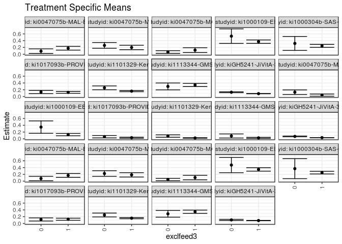

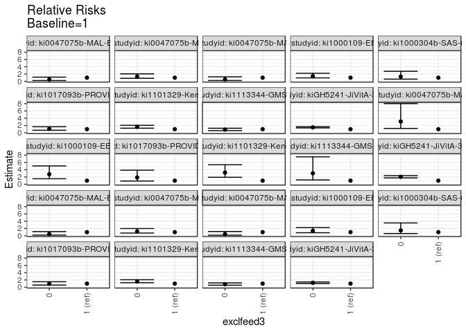

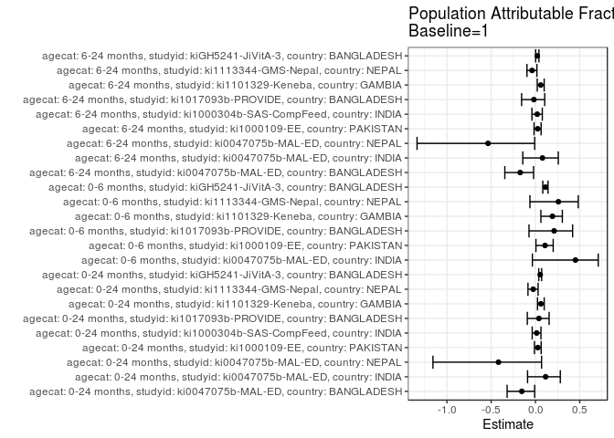

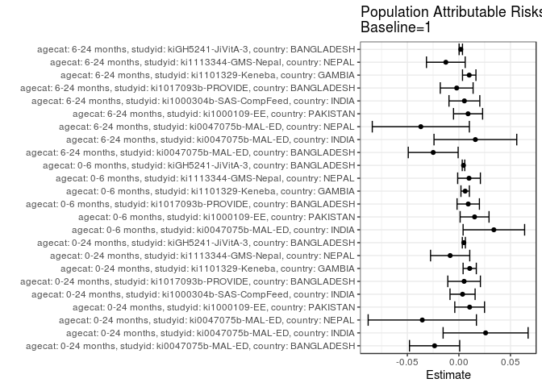

## Results Table

### Parameter: TSM

| agecat | studyid | country | intervention_level | baseline_level | estimate | ci_lower | ci_upper |
| --- | --- | --- | --- | --- | --- | --- | --- |
| 0-24 months | ki0047075b-MAL-ED | BANGLADESH | 1 | NA | 0.1767956 | 0.1211058 | 0.2324854 |
| 0-24 months | ki0047075b-MAL-ED | BANGLADESH | 0 | NA | 0.0895522 | 0.0210423 | 0.1580622 |
| 0-24 months | ki0047075b-MAL-ED | INDIA | 1 | NA | 0.1990988 | 0.1339837 | 0.2642140 |
| 0-24 months | ki0047075b-MAL-ED | INDIA | 0 | NA | 0.2603223 | 0.1752855 | 0.3453592 |
| 0-24 months | ki0047075b-MAL-ED | NEPAL | 1 | NA | 0.1206040 | 0.0498282 | 0.1913797 |
| 0-24 months | ki0047075b-MAL-ED | NEPAL | 0 | NA | 0.0644997 | 0.0247923 | 0.1042071 |
| 0-24 months | ki1000109-EE | PAKISTAN | 1 | NA | 0.3705133 | 0.3198577 | 0.4211688 |
| 0-24 months | ki1000109-EE | PAKISTAN | 0 | NA | 0.5333758 | 0.3186974 | 0.7480542 |
| 0-24 months | ki1000304b-SAS-CompFeed | INDIA | 1 | NA | 0.2464455 | 0.2022875 | 0.2906035 |
| 0-24 months | ki1000304b-SAS-CompFeed | INDIA | 0 | NA | 0.3181818 | 0.1124254 | 0.5239382 |
| 0-24 months | ki1017093b-PROVIDE | BANGLADESH | 1 | NA | 0.1235144 | 0.0945869 | 0.1524420 |
| 0-24 months | ki1017093b-PROVIDE | BANGLADESH | 0 | NA | 0.1336823 | 0.0848843 | 0.1824803 |
| 0-24 months | ki1101329-Keneba | GAMBIA | 1 | NA | 0.1584103 | 0.1415676 | 0.1752530 |
| 0-24 months | ki1101329-Keneba | GAMBIA | 0 | NA | 0.2563147 | 0.1997986 | 0.3128309 |
| 0-24 months | ki1113344-GMS-Nepal | NEPAL | 1 | NA | 0.3411014 | 0.2941411 | 0.3880618 |
| 0-24 months | ki1113344-GMS-Nepal | NEPAL | 0 | NA | 0.2976426 | 0.1967448 | 0.3985404 |
| 0-24 months | kiGH5241-JiVitA-3 | BANGLADESH | 1 | NA | 0.0845381 | 0.0805483 | 0.0885279 |
| 0-24 months | kiGH5241-JiVitA-3 | BANGLADESH | 0 | NA | 0.1263689 | 0.1132605 | 0.1394772 |
| 0-6 months | ki0047075b-MAL-ED | INDIA | 1 | NA | 0.0410959 | 0.0088284 | 0.0733634 |
| 0-6 months | ki0047075b-MAL-ED | INDIA | 0 | NA | 0.1276596 | 0.0600574 | 0.1952617 |
| 0-6 months | ki1000109-EE | PAKISTAN | 1 | NA | 0.1250000 | 0.0904052 | 0.1595948 |
| 0-6 months | ki1000109-EE | PAKISTAN | 0 | NA | 0.3461538 | 0.1630451 | 0.5292626 |
| 0-6 months | ki1017093b-PROVIDE | BANGLADESH | 1 | NA | 0.0338024 | 0.0179928 | 0.0496120 |
| 0-6 months | ki1017093b-PROVIDE | BANGLADESH | 0 | NA | 0.0629883 | 0.0276455 | 0.0983310 |
| 0-6 months | ki1101329-Keneba | GAMBIA | 1 | NA | 0.0256184 | 0.0183197 | 0.0329171 |
| 0-6 months | ki1101329-Keneba | GAMBIA | 0 | NA | 0.0822286 | 0.0469372 | 0.1175201 |
| 0-6 months | ki1113344-GMS-Nepal | NEPAL | 1 | NA | 0.0280612 | 0.0116955 | 0.0444270 |
| 0-6 months | ki1113344-GMS-Nepal | NEPAL | 0 | NA | 0.0843373 | 0.0244901 | 0.1441846 |
| 0-6 months | kiGH5241-JiVitA-3 | BANGLADESH | 1 | NA | 0.0350778 | 0.0326353 | 0.0375203 |
| 0-6 months | kiGH5241-JiVitA-3 | BANGLADESH | 0 | NA | 0.0716970 | 0.0613635 | 0.0820305 |
| 6-24 months | ki0047075b-MAL-ED | BANGLADESH | 1 | NA | 0.1695906 | 0.1132239 | 0.2259574 |
| 6-24 months | ki0047075b-MAL-ED | BANGLADESH | 0 | NA | 0.0781250 | 0.0122357 | 0.1440143 |
| 6-24 months | ki0047075b-MAL-ED | INDIA | 1 | NA | 0.1857296 | 0.1216243 | 0.2498349 |
| 6-24 months | ki0047075b-MAL-ED | INDIA | 0 | NA | 0.2251384 | 0.1427037 | 0.3075731 |
| 6-24 months | ki0047075b-MAL-ED | NEPAL | 1 | NA | 0.1058824 | 0.0403304 | 0.1714343 |
| 6-24 months | ki0047075b-MAL-ED | NEPAL | 0 | NA | 0.0476190 | 0.0131187 | 0.0821194 |
| 6-24 months | ki1000109-EE | PAKISTAN | 1 | NA | 0.3459455 | 0.2958032 | 0.3960877 |
| 6-24 months | ki1000109-EE | PAKISTAN | 0 | NA | 0.4747855 | 0.2489218 | 0.7006492 |
| 6-24 months | ki1000304b-SAS-CompFeed | INDIA | 1 | NA | 0.2512563 | 0.2120897 | 0.2904228 |
| 6-24 months | ki1000304b-SAS-CompFeed | INDIA | 0 | NA | 0.3684211 | 0.0727072 | 0.6641349 |
| 6-24 months | ki1017093b-PROVIDE | BANGLADESH | 1 | NA | 0.1242773 | 0.0931810 | 0.1553736 |
| 6-24 months | ki1017093b-PROVIDE | BANGLADESH | 0 | NA | 0.1185511 | 0.0723836 | 0.1647186 |
| 6-24 months | ki1101329-Keneba | GAMBIA | 1 | NA | 0.1554342 | 0.1382302 | 0.1726382 |
| 6-24 months | ki1101329-Keneba | GAMBIA | 0 | NA | 0.2500153 | 0.1933769 | 0.3066537 |
| 6-24 months | ki1113344-GMS-Nepal | NEPAL | 1 | NA | 0.3459954 | 0.2986238 | 0.3933670 |
| 6-24 months | ki1113344-GMS-Nepal | NEPAL | 0 | NA | 0.2847352 | 0.1851243 | 0.3843461 |
| 6-24 months | kiGH5241-JiVitA-3 | BANGLADESH | 1 | NA | 0.0852383 | 0.0803716 | 0.0901050 |
| 6-24 months | kiGH5241-JiVitA-3 | BANGLADESH | 0 | NA | 0.1044482 | 0.0874806 | 0.1214157 |

### Parameter: E(Y)

| agecat | studyid | country | intervention_level | baseline_level | estimate | ci_lower | ci_upper |
| --- | --- | --- | --- | --- | --- | --- | --- |
| 0-24 months | ki0047075b-MAL-ED | BANGLADESH | NA | NA | 0.1532258 | 0.1083048 | 0.1981468 |
| 0-24 months | ki0047075b-MAL-ED | INDIA | NA | NA | 0.2250000 | 0.1720591 | 0.2779409 |
| 0-24 months | ki0047075b-MAL-ED | NEPAL | NA | NA | 0.0851064 | 0.0493539 | 0.1208589 |
| 0-24 months | ki1000109-EE | PAKISTAN | NA | NA | 0.3809524 | 0.3319322 | 0.4299725 |
| 0-24 months | ki1000304b-SAS-CompFeed | INDIA | NA | NA | 0.2500000 | 0.2118239 | 0.2881761 |
| 0-24 months | ki1017093b-PROVIDE | BANGLADESH | NA | NA | 0.1285714 | 0.1037574 | 0.1533855 |
| 0-24 months | ki1101329-Keneba | GAMBIA | NA | NA | 0.1688955 | 0.1525490 | 0.1852420 |
| 0-24 months | ki1113344-GMS-Nepal | NEPAL | NA | NA | 0.3326316 | 0.2902162 | 0.3750470 |
| 0-24 months | kiGH5241-JiVitA-3 | BANGLADESH | NA | NA | 0.0893460 | 0.0853745 | 0.0933175 |
| 0-6 months | ki0047075b-MAL-ED | INDIA | NA | NA | 0.0750000 | 0.0416074 | 0.1083926 |
| 0-6 months | ki1000109-EE | PAKISTAN | NA | NA | 0.1402116 | 0.1051635 | 0.1752598 |
| 0-6 months | ki1017093b-PROVIDE | BANGLADESH | NA | NA | 0.0428571 | 0.0278427 | 0.0578716 |
| 0-6 months | ki1101329-Keneba | GAMBIA | NA | NA | 0.0316989 | 0.0240550 | 0.0393428 |
| 0-6 months | ki1113344-GMS-Nepal | NEPAL | NA | NA | 0.0378947 | 0.0207054 | 0.0550841 |
| 0-6 months | kiGH5241-JiVitA-3 | BANGLADESH | NA | NA | 0.0395463 | 0.0370065 | 0.0420860 |
| 6-24 months | ki0047075b-MAL-ED | BANGLADESH | NA | NA | 0.1446809 | 0.0996085 | 0.1897532 |
| 6-24 months | ki0047075b-MAL-ED | INDIA | NA | NA | 0.2017167 | 0.1500806 | 0.2533529 |
| 6-24 months | ki0047075b-MAL-ED | NEPAL | NA | NA | 0.0689655 | 0.0362886 | 0.1016424 |
| 6-24 months | ki1000109-EE | PAKISTAN | NA | NA | 0.3548387 | 0.3061520 | 0.4035255 |
| 6-24 months | ki1000304b-SAS-CompFeed | INDIA | NA | NA | 0.2565947 | 0.2209578 | 0.2922316 |
| 6-24 months | ki1017093b-PROVIDE | BANGLADESH | NA | NA | 0.1221498 | 0.0962275 | 0.1480722 |
| 6-24 months | ki1101329-Keneba | GAMBIA | NA | NA | 0.1654450 | 0.1487764 | 0.1821136 |
| 6-24 months | ki1113344-GMS-Nepal | NEPAL | NA | NA | 0.3333333 | 0.2905787 | 0.3760880 |
| 6-24 months | kiGH5241-JiVitA-3 | BANGLADESH | NA | NA | 0.0870892 | 0.0823628 | 0.0918157 |

### Parameter: RR

| agecat | studyid | country | intervention_level | baseline_level | estimate | ci_lower | ci_upper |
| --- | --- | --- | --- | --- | --- | --- | --- |
| 0-24 months | ki0047075b-MAL-ED | BANGLADESH | 1 | 1 | 1.0000000 | 1.0000000 | 1.000000 |
| 0-24 months | ki0047075b-MAL-ED | BANGLADESH | 0 | 1 | 0.5065299 | 0.2214605 | 1.158548 |
| 0-24 months | ki0047075b-MAL-ED | INDIA | 1 | 1 | 1.0000000 | 1.0000000 | 1.000000 |
| 0-24 months | ki0047075b-MAL-ED | INDIA | 0 | 1 | 1.3075029 | 0.8343078 | 2.049081 |
| 0-24 months | ki0047075b-MAL-ED | NEPAL | 1 | 1 | 1.0000000 | 1.0000000 | 1.000000 |
| 0-24 months | ki0047075b-MAL-ED | NEPAL | 0 | 1 | 0.5348059 | 0.2303918 | 1.241438 |
| 0-24 months | ki1000109-EE | PAKISTAN | 1 | 1 | 1.0000000 | 1.0000000 | 1.000000 |
| 0-24 months | ki1000109-EE | PAKISTAN | 0 | 1 | 1.4395592 | 0.9412269 | 2.201733 |
| 0-24 months | ki1000304b-SAS-CompFeed | INDIA | 1 | 1 | 1.0000000 | 1.0000000 | 1.000000 |
| 0-24 months | ki1000304b-SAS-CompFeed | INDIA | 0 | 1 | 1.2910839 | 0.6050646 | 2.754908 |
| 0-24 months | ki1017093b-PROVIDE | BANGLADESH | 1 | 1 | 1.0000000 | 1.0000000 | 1.000000 |
| 0-24 months | ki1017093b-PROVIDE | BANGLADESH | 0 | 1 | 1.0823213 | 0.7020011 | 1.668686 |
| 0-24 months | ki1101329-Keneba | GAMBIA | 1 | 1 | 1.0000000 | 1.0000000 | 1.000000 |
| 0-24 months | ki1101329-Keneba | GAMBIA | 0 | 1 | 1.6180432 | 1.2689044 | 2.063247 |
| 0-24 months | ki1113344-GMS-Nepal | NEPAL | 1 | 1 | 1.0000000 | 1.0000000 | 1.000000 |
| 0-24 months | ki1113344-GMS-Nepal | NEPAL | 0 | 1 | 0.8725926 | 0.6055131 | 1.257475 |
| 0-24 months | kiGH5241-JiVitA-3 | BANGLADESH | 1 | 1 | 1.0000000 | 1.0000000 | 1.000000 |
| 0-24 months | kiGH5241-JiVitA-3 | BANGLADESH | 0 | 1 | 1.4948157 | 1.3404659 | 1.666938 |
| 0-6 months | ki0047075b-MAL-ED | INDIA | 1 | 1 | 1.0000000 | 1.0000000 | 1.000000 |
| 0-6 months | ki0047075b-MAL-ED | INDIA | 0 | 1 | 3.1063830 | 1.2049021 | 8.008630 |
| 0-6 months | ki1000109-EE | PAKISTAN | 1 | 1 | 1.0000000 | 1.0000000 | 1.000000 |
| 0-6 months | ki1000109-EE | PAKISTAN | 0 | 1 | 2.7692308 | 1.5243435 | 5.030781 |
| 0-6 months | ki1017093b-PROVIDE | BANGLADESH | 1 | 1 | 1.0000000 | 1.0000000 | 1.000000 |
| 0-6 months | ki1017093b-PROVIDE | BANGLADESH | 0 | 1 | 1.8634273 | 0.8962603 | 3.874278 |
| 0-6 months | ki1101329-Keneba | GAMBIA | 1 | 1 | 1.0000000 | 1.0000000 | 1.000000 |
| 0-6 months | ki1101329-Keneba | GAMBIA | 0 | 1 | 3.2097505 | 1.9187773 | 5.369304 |
| 0-6 months | ki1113344-GMS-Nepal | NEPAL | 1 | 1 | 1.0000000 | 1.0000000 | 1.000000 |
| 0-6 months | ki1113344-GMS-Nepal | NEPAL | 0 | 1 | 3.0054765 | 1.1995016 | 7.530535 |
| 0-6 months | kiGH5241-JiVitA-3 | BANGLADESH | 1 | 1 | 1.0000000 | 1.0000000 | 1.000000 |
| 0-6 months | kiGH5241-JiVitA-3 | BANGLADESH | 0 | 1 | 2.0439411 | 1.7542129 | 2.381521 |
| 6-24 months | ki0047075b-MAL-ED | BANGLADESH | 1 | 1 | 1.0000000 | 1.0000000 | 1.000000 |
| 6-24 months | ki0047075b-MAL-ED | BANGLADESH | 0 | 1 | 0.4606681 | 0.1860779 | 1.140464 |
| 6-24 months | ki0047075b-MAL-ED | INDIA | 1 | 1 | 1.0000000 | 1.0000000 | 1.000000 |
| 6-24 months | ki0047075b-MAL-ED | INDIA | 0 | 1 | 1.2121841 | 0.7407814 | 1.983568 |
| 6-24 months | ki0047075b-MAL-ED | NEPAL | 1 | 1 | 1.0000000 | 1.0000000 | 1.000000 |
| 6-24 months | ki0047075b-MAL-ED | NEPAL | 0 | 1 | 0.4497355 | 0.1734112 | 1.166372 |
| 6-24 months | ki1000109-EE | PAKISTAN | 1 | 1 | 1.0000000 | 1.0000000 | 1.000000 |
| 6-24 months | ki1000109-EE | PAKISTAN | 0 | 1 | 1.3724288 | 0.8344803 | 2.257166 |
| 6-24 months | ki1000304b-SAS-CompFeed | INDIA | 1 | 1 | 1.0000000 | 1.0000000 | 1.000000 |
| 6-24 months | ki1000304b-SAS-CompFeed | INDIA | 0 | 1 | 1.4663158 | 0.6118309 | 3.514177 |
| 6-24 months | ki1017093b-PROVIDE | BANGLADESH | 1 | 1 | 1.0000000 | 1.0000000 | 1.000000 |
| 6-24 months | ki1017093b-PROVIDE | BANGLADESH | 0 | 1 | 0.9539237 | 0.6031684 | 1.508651 |
| 6-24 months | ki1101329-Keneba | GAMBIA | 1 | 1 | 1.0000000 | 1.0000000 | 1.000000 |
| 6-24 months | ki1101329-Keneba | GAMBIA | 0 | 1 | 1.6084958 | 1.2525593 | 2.065578 |
| 6-24 months | ki1113344-GMS-Nepal | NEPAL | 1 | 1 | 1.0000000 | 1.0000000 | 1.000000 |
| 6-24 months | ki1113344-GMS-Nepal | NEPAL | 0 | 1 | 0.8229450 | 0.5658392 | 1.196875 |
| 6-24 months | kiGH5241-JiVitA-3 | BANGLADESH | 1 | 1 | 1.0000000 | 1.0000000 | 1.000000 |
| 6-24 months | kiGH5241-JiVitA-3 | BANGLADESH | 0 | 1 | 1.2253662 | 1.0344307 | 1.451545 |

### Parameter: PAR

| agecat | studyid | country | intervention_level | baseline_level | estimate | ci_lower | ci_upper |
| --- | --- | --- | --- | --- | --- | --- | --- |
| 0-24 months | ki0047075b-MAL-ED | BANGLADESH | 1 | NA | -0.0235698 | -0.0479064 | 0.0007669 |
| 0-24 months | ki0047075b-MAL-ED | INDIA | 1 | NA | 0.0259012 | -0.0153120 | 0.0671143 |
| 0-24 months | ki0047075b-MAL-ED | NEPAL | 1 | NA | -0.0354976 | -0.0879885 | 0.0169933 |
| 0-24 months | ki1000109-EE | PAKISTAN | 1 | NA | 0.0104391 | -0.0039826 | 0.0248608 |
| 0-24 months | ki1000304b-SAS-CompFeed | INDIA | 1 | NA | 0.0035545 | -0.0086130 | 0.0157220 |
| 0-24 months | ki1017093b-PROVIDE | BANGLADESH | 1 | NA | 0.0050570 | -0.0107489 | 0.0208629 |
| 0-24 months | ki1101329-Keneba | GAMBIA | 1 | NA | 0.0104852 | 0.0040814 | 0.0168889 |
| 0-24 months | ki1113344-GMS-Nepal | NEPAL | 1 | NA | -0.0084699 | -0.0274756 | 0.0105359 |
| 0-24 months | kiGH5241-JiVitA-3 | BANGLADESH | 1 | NA | 0.0048079 | 0.0033229 | 0.0062930 |
| 0-6 months | ki0047075b-MAL-ED | INDIA | 1 | NA | 0.0339041 | 0.0040800 | 0.0637282 |
| 0-6 months | ki1000109-EE | PAKISTAN | 1 | NA | 0.0152116 | 0.0012041 | 0.0292192 |
| 0-6 months | ki1017093b-PROVIDE | BANGLADESH | 1 | NA | 0.0090548 | -0.0017861 | 0.0198956 |
| 0-6 months | ki1101329-Keneba | GAMBIA | 1 | NA | 0.0060805 | 0.0019938 | 0.0101672 |
| 0-6 months | ki1113344-GMS-Nepal | NEPAL | 1 | NA | 0.0098335 | -0.0011773 | 0.0208444 |
| 0-6 months | kiGH5241-JiVitA-3 | BANGLADESH | 1 | NA | 0.0044684 | 0.0032444 | 0.0056925 |
| 6-24 months | ki0047075b-MAL-ED | BANGLADESH | 1 | NA | -0.0249098 | -0.0490938 | -0.0007258 |
| 6-24 months | ki0047075b-MAL-ED | INDIA | 1 | NA | 0.0159872 | -0.0241266 | 0.0561009 |
| 6-24 months | ki0047075b-MAL-ED | NEPAL | 1 | NA | -0.0369168 | -0.0839927 | 0.0101590 |
| 6-24 months | ki1000109-EE | PAKISTAN | 1 | NA | 0.0088933 | -0.0052055 | 0.0229920 |
| 6-24 months | ki1000304b-SAS-CompFeed | INDIA | 1 | NA | 0.0053384 | -0.0095993 | 0.0202761 |
| 6-24 months | ki1017093b-PROVIDE | BANGLADESH | 1 | NA | -0.0021275 | -0.0180400 | 0.0137850 |
| 6-24 months | ki1101329-Keneba | GAMBIA | 1 | NA | 0.0100108 | 0.0034977 | 0.0165240 |
| 6-24 months | ki1113344-GMS-Nepal | NEPAL | 1 | NA | -0.0126621 | -0.0314422 | 0.0061181 |
| 6-24 months | kiGH5241-JiVitA-3 | BANGLADESH | 1 | NA | 0.0018509 | 0.0002202 | 0.0034817 |

### Parameter: PAF

| agecat | studyid | country | intervention_level | baseline_level | estimate | ci_lower | ci_upper |
| --- | --- | --- | --- | --- | --- | --- | --- |
| 0-24 months | ki0047075b-MAL-ED | BANGLADESH | 1 | NA | -0.1538238 | -0.3197802 | -0.0087356 |
| 0-24 months | ki0047075b-MAL-ED | INDIA | 1 | NA | 0.1151163 | -0.0888578 | 0.2808803 |
| 0-24 months | ki0047075b-MAL-ED | NEPAL | 1 | NA | -0.4170967 | -1.1576356 | 0.0692761 |
| 0-24 months | ki1000109-EE | PAKISTAN | 1 | NA | 0.0274027 | -0.0112547 | 0.0645823 |
| 0-24 months | ki1000304b-SAS-CompFeed | INDIA | 1 | NA | 0.0142180 | -0.0365627 | 0.0625110 |
| 0-24 months | ki1017093b-PROVIDE | BANGLADESH | 1 | NA | 0.0393323 | -0.0917653 | 0.1546878 |
| 0-24 months | ki1101329-Keneba | GAMBIA | 1 | NA | 0.0620809 | 0.0236268 | 0.0990205 |
| 0-24 months | ki1113344-GMS-Nepal | NEPAL | 1 | NA | -0.0254632 | -0.0842241 | 0.0301132 |
| 0-24 months | kiGH5241-JiVitA-3 | BANGLADESH | 1 | NA | 0.0538124 | 0.0372961 | 0.0700453 |
| 0-6 months | ki0047075b-MAL-ED | INDIA | 1 | NA | 0.4520548 | -0.0343995 | 0.7097408 |
| 0-6 months | ki1000109-EE | PAKISTAN | 1 | NA | 0.1084906 | 0.0057298 | 0.2006307 |
| 0-6 months | ki1017093b-PROVIDE | BANGLADESH | 1 | NA | 0.2112780 | -0.0725179 | 0.4199794 |
| 0-6 months | ki1101329-Keneba | GAMBIA | 1 | NA | 0.1918199 | 0.0615477 | 0.3040083 |
| 0-6 months | ki1113344-GMS-Nepal | NEPAL | 1 | NA | 0.2594955 | -0.0622319 | 0.4837785 |
| 0-6 months | kiGH5241-JiVitA-3 | BANGLADESH | 1 | NA | 0.1129928 | 0.0830453 | 0.1419623 |
| 6-24 months | ki0047075b-MAL-ED | BANGLADESH | 1 | NA | -0.1721706 | -0.3457595 | -0.0209729 |
| 6-24 months | ki0047075b-MAL-ED | INDIA | 1 | NA | 0.0792555 | -0.1429905 | 0.2582874 |
| 6-24 months | ki0047075b-MAL-ED | NEPAL | 1 | NA | -0.5352941 | -1.3371869 | -0.0085321 |
| 6-24 months | ki1000109-EE | PAKISTAN | 1 | NA | 0.0250628 | -0.0155024 | 0.0640076 |
| 6-24 months | ki1000304b-SAS-CompFeed | INDIA | 1 | NA | 0.0208050 | -0.0393691 | 0.0774953 |
| 6-24 months | ki1017093b-PROVIDE | BANGLADESH | 1 | NA | -0.0174168 | -0.1562414 | 0.1047397 |
| 6-24 months | ki1101329-Keneba | GAMBIA | 1 | NA | 0.0605084 | 0.0205239 | 0.0988606 |
| 6-24 months | ki1113344-GMS-Nepal | NEPAL | 1 | NA | -0.0379862 | -0.0959031 | 0.0168698 |
| 6-24 months | kiGH5241-JiVitA-3 | BANGLADESH | 1 | NA | 0.0212532 | 0.0024121 | 0.0397384 |